# Homework 04: Tidy data and joins

Shuxian Fan

Oct 4th, 2018

## Initial Package Set-up

```r
suppressPackageStartupMessages(library(gapminder))
suppressPackageStartupMessages(library(kableExtra))
suppressPackageStartupMessages(library(tidyverse))
suppressPackageStartupMessages(library(geonames))
suppressPackageStartupMessages(library(devtools))
suppressPackageStartupMessages(library(rjson))
require(devtools)
install_github("ropensci/geonames")
```

```
## Skipping install of 'geonames' from a github remote, the SHA1 (e90cd742) has not changed since last install.
##   Use `force = TRUE` to force installation
```

## 1 Data Reshaping Prompts - **Activity #2**

### 1.1 Make a tibble with one row per year and columns for life expectancy for countries in Oceania.

For this task, I select all the countries that are in `Oceania` continent. There are only two countries in the gapminder dataset that are in Oceania, which are Australia and New Zealand. And I will spread the `lifeExp` of each year for the two countries.

```r
# Get the sub dataset that contains the information of countries in Oceania
gap_Oceania = gapminder%>%
  filter(continent == "Oceania") %>%
  select(country,lifeExp, year)

# Take a look at this sub dataset.
knitr::kable(gap_Oceania,"html", caption = "Sub-dataset of Gapminder with countries in Oceania")%>%
  kable_styling(bootstrap_options = "striped", full_width = F)%>%
  row_spec(0, bold = T, color = "black", background = "#E6E6FA" )%>%
  scroll_box(width = "800px", height = "400px")
```

Sub-dataset of Gapminder with countries in Oceania

| country | lifeExp | year |
| --- | --- | --- |
| Australia | 69.120 | 1952 |
| Australia | 70.330 | 1957 |
| Australia | 70.930 | 1962 |
| Australia | 71.100 | 1967 |
| Australia | 71.930 | 1972 |
| Australia | 73.490 | 1977 |
| Australia | 74.740 | 1982 |
| Australia | 76.320 | 1987 |
| Australia | 77.560 | 1992 |
| Australia | 78.830 | 1997 |
| Australia | 80.370 | 2002 |
| Australia | 81.235 | 2007 |
| New Zealand | 69.390 | 1952 |
| New Zealand | 70.260 | 1957 |
| New Zealand | 71.240 | 1962 |
| New Zealand | 71.520 | 1967 |
| New Zealand | 71.890 | 1972 |
| New Zealand | 72.220 | 1977 |
| New Zealand | 73.840 | 1982 |
| New Zealand | 74.320 | 1987 |
| New Zealand | 76.330 | 1992 |
| New Zealand | 77.550 | 1997 |
| New Zealand | 79.110 | 2002 |
| New Zealand | 80.204 | 2007 |

```r
# Spread the lifeExp and make one row per year.
gap_Oceania_tbl = gap_Oceania %>%
  spread(key = country, value = lifeExp) %>%
  tibble::as.tibble()

class(gap_Oceania_tbl)
```

```
## [1] "tbl_df"     "tbl"        "data.frame"
```

```r
# Take a look at our new tbl
knitr::kable(gap_Oceania_tbl,"html", caption = "New Dataframe with one row per year for life expectancy for countries in Oceania")%>%
  kable_styling(bootstrap_options = "striped", full_width = F)%>%
  row_spec(0, bold = T, color = "black", background = "#E6E6FA" )%>%
  scroll_box(width = "800px", height = "400px")
```

New Dataframe with one row per year for life expectancy for countries in Oceania

| year | Australia | New Zealand |
| --- | --- | --- |
| 1952 | 69.120 | 69.390 |
| 1957 | 70.330 | 70.260 |
| 1962 | 70.930 | 71.240 |
| 1967 | 71.100 | 71.520 |
| 1972 | 71.930 | 71.890 |
| 1977 | 73.490 | 72.220 |
| 1982 | 74.740 | 73.840 |
| 1987 | 76.320 | 74.320 |
| 1992 | 77.560 | 76.330 |
| 1997 | 78.830 | 77.550 |
| 2002 | 80.370 | 79.110 |
| 2007 | 81.235 | 80.204 |

### 1.2 Make a scatterplot of `lifeExp` for Australia and New Zealand using the tbl.

The space between the name of “New Zealand” is not quite convenient for calling it in the function. So I first rename the column names of our new tbl. Then using the `ggplot2`, I made a scatterplot of the two countries’ life expectancy over years. I added a scale color gradient so that year informatio can be shown in the plot. From the plot and a smooth fitting we can see that there is positive and approximately linear relationship between the life expectancy of Australia and New Zealand. This is not odd to observe as they are countries from the same continent. Also the ranges of the life expectancy for both countries are very similar by looking at the plot axis.

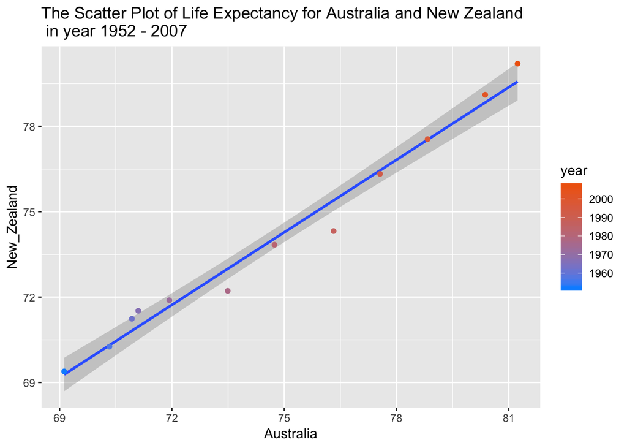

```r
# rename the name "New Zealand" to "New_Zealand"
colnames(gap_Oceania_tbl)[colnames(gap_Oceania_tbl) == "New Zealand"] <- "New_Zealand"

# create the scatterplot for Australia and New Zealand and adding a linear fit of the points.
gap_Oceania_tbl %>%
  ggplot(aes(Australia, New_Zealand))+
  geom_smooth(method = "lm")+
  geom_point(aes(color = year))+
  scale_color_gradient(low = "#0091ff", high = "#f0650e")+  # add gradient scale color to illustrate the year
  ggtitle("The Scatter Plot of Life Expectancy for Australia and New Zealand \n in year 1952 - 2007")
```

## 2 Join Prompts - **Activity #1**

### 2.1 Creating the Example Data Frames

1. Create a second data frame, complementary to Gapminder.
2. Join this with (part of) Gapminder using a `dplyr` join function and make some observations about the process and result. Explore the different types of joins._

In terms of incorporating more informations of the country, I will be using the data from the package `geonames`. In order to get access to the geonames database, I refered to this [GitHub Repository](https://github.com/ropensci/geonames) providing an R package for accessing the geonames.org API.

The dataset I am about to use comes from using the function `CNcountryInfo()` in the `geonames` package. This dataframe has 17 variables containing the information for different countries.

```r
# get the dataframe of countryInfo from geonames packages.
# options(geonamesUsername = "shuxian.fan")
# countryInfo = geonames::GNcountryInfo()
# In order to avoid calling to the server everytime, I write the data into csv files
# write_csv(countryInfo, "countryInfo.csv")

countryInfo = read.csv("countryInfo.csv")
# check out the data type and variables
class(countryInfo)
```

```
## [1] "data.frame"
```

```r
str(countryInfo)
```

```
## 'data.frame':    250 obs. of  17 variables:
##  $ continent    : Factor w/ 6 levels "AF","AN","AS",..: 4 3 3 NA NA 4 3 1 2 6 ...
##  $ capital      : Factor w/ 241 levels "Abu Dhabi","Abuja",..: 10 1 91 187 216 218 240 112 NA 45 ...
##  $ languages    : Factor w/ 244 levels "aa-ER,ar,tig,kun,ti-ER",..: 30 3 126 43 44 219 162 203 NA 105 ...
##  $ geonameId    : int  3041565 290557 1149361 3576396 3573511 783754 174982 3351879 6697173 3865483 ...
##  $ south        : num  42.4 22.6 29.4 17 18.2 ...
##  $ isoAlpha3    : Factor w/ 250 levels "ABW","AFG","AGO",..: 7 8 2 14 4 6 10 3 12 9 ...
##  $ north        : num  42.7 26.1 38.5 17.7 18.3 ...
##  $ fipsCode     : Factor w/ 247 levels "AA","AC","AE",..: 9 3 4 2 15 7 8 10 16 12 ...
##  $ population   : int  84000 4975593 29121286 86754 13254 2986952 2968000 13068161 0 41343201 ...
##  $ east         : num  1.79 56.38 74.89 -61.67 -62.97 ...
##  $ isoNumeric   : int  20 784 4 28 660 8 51 24 10 32 ...
##  $ areaInSqKm   : num  468 82880 647500 443 102 ...
##  $ countryCode  : Factor w/ 249 levels "AD","AE","AF",..: 1 2 3 4 5 6 7 8 9 10 ...
##  $ west         : num  1.41 51.57 60.47 -61.91 -63.17 ...
##  $ countryName  : Factor w/ 250 levels "Ahvenanmaa","Al Mamlakah al Urdunīyah al Hāshimīyah",..: 115 243 69 6 4 121 123 122 5 8 ...
##  $ continentName: Factor w/ 7 levels "Africa","Antarctica",..: 4 3 3 5 5 4 3 1 2 7 ...
##  $ currencyCode : Factor w/ 155 levels "AED","AFN","ALL",..: 43 1 2 149 149 3 4 6 NA 7 ...
```

In terms of simplification, I will take a relatively small subset of the `gapminder` dataset for further illustration.

```r
# get the data for countries in Europe after year 2000
gap_Europe = gapminder%>%
  filter(continent=="Europe"&year> 2000)%>%
  select(country, year, lifeExp, pop, gdpPercap)
```

I found that for some countries, the country names are defined differently in the two datasets. For example, the country “Finland” in `gapminder` is named as “Republic of Finland” in the `countryInfo`. Therefore I decide to add the country code information to the `gap_Europe` I just created so that the merging of the data will not cause any conflicts. Luckily, `gapminder` package also has the `country_codes` dataframe, where the The 3-letter ISO 3166-1 alpha-3 code for each country are provided. When merging the country code information into my sub-dataset, there is a warning message that reads:

*“Column `country` joining factor and character vector, coercing into character vector”*

I found [this page](https://rpubs.com/hadley/45044) gives a relatively clear explanation on why `dplyr` will produce such warnings. When joining tables, dplyr is a little more conservative than base R about what types of variable it considers equivalent. This is mostly likely to cause you problems if you’re using factors.

```r
# get the country code (isoalpha3)
code = country_codes%>%select(country,iso_alpha)
# change the column names to be the same as the countryInfo
colnames(code)[colnames(code)=="iso_alpha"] <- "isoAlpha3"

# create new dataset with code information merged.
gap_Europe_new =
  left_join(gap_Europe, code,by = "country")
```

```
## Warning: Column `country` joining factor and character vector, coercing
## into character vector
```

```r
knitr::kable(gap_Europe_new,"html", caption = "Gapminder Subset with country code added")%>%
  kable_styling(bootstrap_options = "striped", full_width = F)%>%
  row_spec(0, bold = T, color = "black", background = "#E6E6FA" )%>%
  scroll_box(width = "800px", height = "400px")
```

Gapminder Subset with country code added

| country | year | lifeExp | pop | gdpPercap | isoAlpha3 |
| --- | --- | --- | --- | --- | --- |
| Albania | 2002 | 75.651 | 3508512 | 4604.212 | ALB |
| Albania | 2007 | 76.423 | 3600523 | 5937.030 | ALB |
| Austria | 2002 | 78.980 | 8148312 | 32417.608 | AUT |
| Austria | 2007 | 79.829 | 8199783 | 36126.493 | AUT |
| Belgium | 2002 | 78.320 | 10311970 | 30485.884 | BEL |
| Belgium | 2007 | 79.441 | 10392226 | 33692.605 | BEL |
| Bosnia and Herzegovina | 2002 | 74.090 | 4165416 | 6018.975 | BIH |
| Bosnia and Herzegovina | 2007 | 74.852 | 4552198 | 7446.299 | BIH |
| Bulgaria | 2002 | 72.140 | 7661799 | 7696.778 | BGR |
| Bulgaria | 2007 | 73.005 | 7322858 | 10680.793 | BGR |
| Croatia | 2002 | 74.876 | 4481020 | 11628.389 | HRV |
| Croatia | 2007 | 75.748 | 4493312 | 14619.223 | HRV |
| Czech Republic | 2002 | 75.510 | 10256295 | 17596.210 | CZE |
| Czech Republic | 2007 | 76.486 | 10228744 | 22833.309 | CZE |
| Denmark | 2002 | 77.180 | 5374693 | 32166.500 | DNK |
| Denmark | 2007 | 78.332 | 5468120 | 35278.419 | DNK |
| Finland | 2002 | 78.370 | 5193039 | 28204.591 | FIN |
| Finland | 2007 | 79.313 | 5238460 | 33207.084 | FIN |
| France | 2002 | 79.590 | 59925035 | 28926.032 | FRA |
| France | 2007 | 80.657 | 61083916 | 30470.017 | FRA |
| Germany | 2002 | 78.670 | 82350671 | 30035.802 | DEU |
| Germany | 2007 | 79.406 | 82400996 | 32170.374 | DEU |
| Greece | 2002 | 78.256 | 10603863 | 22514.255 | GRC |
| Greece | 2007 | 79.483 | 10706290 | 27538.412 | GRC |
| Hungary | 2002 | 72.590 | 10083313 | 14843.936 | HUN |
| Hungary | 2007 | 73.338 | 9956108 | 18008.944 | HUN |
| Iceland | 2002 | 80.500 | 288030 | 31163.202 | ISL |
| Iceland | 2007 | 81.757 | 301931 | 36180.789 | ISL |
| Ireland | 2002 | 77.783 | 3879155 | 34077.049 | IRL |
| Ireland | 2007 | 78.885 | 4109086 | 40675.996 | IRL |
| Italy | 2002 | 80.240 | 57926999 | 27968.098 | ITA |
| Italy | 2007 | 80.546 | 58147733 | 28569.720 | ITA |
| Montenegro | 2002 | 73.981 | 720230 | 6557.194 | MNE |
| Montenegro | 2007 | 74.543 | 684736 | 9253.896 | MNE |
| Netherlands | 2002 | 78.530 | 16122830 | 33724.758 | NLD |
| Netherlands | 2007 | 79.762 | 16570613 | 36797.933 | NLD |
| Norway | 2002 | 79.050 | 4535591 | 44683.975 | NOR |
| Norway | 2007 | 80.196 | 4627926 | 49357.190 | NOR |
| Poland | 2002 | 74.670 | 38625976 | 12002.239 | POL |
| Poland | 2007 | 75.563 | 38518241 | 15389.925 | POL |
| Portugal | 2002 | 77.290 | 10433867 | 19970.908 | PRT |
| Portugal | 2007 | 78.098 | 10642836 | 20509.648 | PRT |
| Romania | 2002 | 71.322 | 22404337 | 7885.360 | ROU |
| Romania | 2007 | 72.476 | 22276056 | 10808.476 | ROU |
| Serbia | 2002 | 73.213 | 10111559 | 7236.075 | SRB |
| Serbia | 2007 | 74.002 | 10150265 | 9786.535 | SRB |
| Slovak Republic | 2002 | 73.800 | 5410052 | 13638.778 | SVK |
| Slovak Republic | 2007 | 74.663 | 5447502 | 18678.314 | SVK |
| Slovenia | 2002 | 76.660 | 2011497 | 20660.019 | SVN |
| Slovenia | 2007 | 77.926 | 2009245 | 25768.258 | SVN |
| Spain | 2002 | 79.780 | 40152517 | 24835.472 | ESP |
| Spain | 2007 | 80.941 | 40448191 | 28821.064 | ESP |
| Sweden | 2002 | 80.040 | 8954175 | 29341.631 | SWE |
| Sweden | 2007 | 80.884 | 9031088 | 33859.748 | SWE |
| Switzerland | 2002 | 80.620 | 7361757 | 34480.958 | CHE |
| Switzerland | 2007 | 81.701 | 7554661 | 37506.419 | CHE |
| Turkey | 2002 | 70.845 | 67308928 | 6508.086 | TUR |
| Turkey | 2007 | 71.777 | 71158647 | 8458.276 | TUR |
| United Kingdom | 2002 | 78.471 | 59912431 | 29478.999 | GBR |
| United Kingdom | 2007 | 79.425 | 60776238 | 33203.261 | GBR |

After creating the subset for the `gapminder`, now I create the second data frame based on the `countryInfo`.

```r
# get the subset of countryInfo dataset filtered by continent Europe.
# selected variables are countryName, isoAlpha3, currencyCode, capital and languages.
countryInfo_sub = countryInfo %>%
  filter(continentName == "Europe") %>%
  select(country = countryName, isoAlpha3, currencyCode, capital = capital, languages)%>%
  mutate(country=as.character(country),
         isoAlpha3=as.character(isoAlpha3),
         capital=as.character(capital),
         languages=as.character(languages))

# I take the subset that only contains countries appeared in the gapminder subset
countryInfo_new = countryInfo_sub %>%
  filter(countryInfo_sub$isoAlpha3 %in% gap_Europe_new$isoAlpha3)

# Take a look at the new subset
knitr::kable(countryInfo_new,"html", caption = "Subset of CountryInfo with countries in Europe")%>%
  kable_styling(bootstrap_options = "striped", full_width = F)%>%
  row_spec(0, bold = T, color = "black", background = "#E6E6FA" )%>%
  scroll_box(width = "800px", height = "400px")
```

Subset of CountryInfo with countries in Europe

| country | isoAlpha3 | currencyCode | capital | languages |
| --- | --- | --- | --- | --- |
| Republic of Albania | ALB | ALL | Tirana | sq,el |
| Republic of Austria | AUT | EUR | Vienna | de-AT,hr,hu,sl |
| Bosnia and Herzegovina | BIH | BAM | Sarajevo | bs,hr-BA,sr-BA |
| Kingdom of Belgium | BEL | EUR | Brussels | nl-BE,fr-BE,de-BE |
| Republic of Bulgaria | BGR | BGN | Sofia | bg,tr-BG,rom |
| Switzerland | CHE | CHF | Bern | de-CH,fr-CH,it-CH,rm |
| Czech Republic | CZE | CZK | Praha | cs,sk |
| Federal Republic of Germany | DEU | EUR | Berlin | de |
| Kingdom of Denmark | DNK | DKK | Copenhagen | da-DK,en,fo,de-DK |
| Kingdom of Spain | ESP | EUR | Madrid | es-ES,ca,gl,eu,oc |
| Republic of Finland | FIN | EUR | Helsinki | fi-FI,sv-FI,smn |
| France | FRA | EUR | Paris | fr-FR,frp,br,co,ca,eu,oc |
| United Kingdom of Great Britain and Northern Ireland | GBR | GBP | London | en-GB,cy-GB,gd |
| Hellenic Republic | GRC | EUR | Athens | el-GR,en,fr |
| Republic of Croatia | HRV | HRK | Zagreb | hr-HR,sr |
| Hungary | HUN | HUF | Budapest | hu-HU |
| Ireland | IRL | EUR | Dublin | en-IE,ga-IE |
| Republic of Iceland | ISL | ISK | Reykjavík | is,en,de,da,sv,no |
| Repubblica Italiana | ITA | EUR | Rome | it-IT,de-IT,fr-IT,sc,ca,co,sl |
| Montenegro | MNE | EUR | Podgorica | sr,hu,bs,sq,hr,rom |
| Kingdom of the Netherlands | NLD | EUR | Amsterdam | nl-NL,fy-NL |
| Kingdom of Norway | NOR | NOK | Oslo | no,nb,nn,se,fi |
| Republic of Poland | POL | PLN | Warsaw | pl |
| Portuguese Republic | PRT | EUR | Lisbon | pt-PT,mwl |
| România | ROU | RON | Bucharest | ro,hu,rom |
| Serbia | SRB | RSD | Belgrade | sr,hu,bs,rom |
| Kingdom of Sweden | SWE | SEK | Stockholm | sv-SE,se,sma,fi-SE |
| Republic of Slovenia | SVN | EUR | Ljubljana | sl,sh |
| Slovak Republic | SVK | EUR | Bratislava | sk,hu |

```r
# I found that the country:
# Turkey with isoAlpha3 "TUR" is in the gapminder subset but not in the countryInfo subset.
unique_ct1 = unique(countryInfo_new$isoAlpha3)
unique_ct2 = unique(gap_Europe_new$isoAlpha3)
unique_ct2[!unique_ct2 %in% unique_ct1]
```

```
## [1] "TUR"
```

With the two toy subsets created, I will present further exploration on the different types of joins. The two sub dataframes are: `gap_Europe_new` and `countryInfo_new`.

**`gap_Europe_new` has 6 variables:**

`country`, `year`, `lifeExp`, `pop`, `gdpPercap`, `isoAlpha3`, each row represents a country in the `Europe` continent originally stored in the `gapminder` dataframe. There are 30 countries’ information stored in `gap_Europe_new` dataframe.

**`countryInfo_new` has 5 variables:**

`country`,`isoAlpha3`,`currencyCode`,`capital`, `languages`, each row represents a country that is classified to be in the continent Europe in both `gapminder` and `countryInfo`. There are 29 countries appear in this subset, without the country `Turkey` which is in the `gap_Europe_new`.

### 2.2 Mutating Joins

#### 2.2.1 left_join(x, y, NULL…)

> Join matching values from y to x

We can see that `left_join` function will keep the observations in x-dataframe and merge the y-dataframe based on the `by = ...` argument. Here the country `Turkey` is kept as it is in x-dataframe even if it is not in y-dataframe.

```r
# str(gap_Europe_new)
# str(countryInfo_new)

# left_join with x = gap_Europe_new and y = countryInfo_new, by country code isoAlpha3.
join_left1 =
  gap_Europe_new %>%
  left_join(countryInfo_new, by = "isoAlpha3")

# Take a look at the result.
knitr::kable(join_left1,"html", caption = "Left_join with x = `gap_Europe_new` and y = `countryInfo_new` by the `isoAlpha3` " )%>%
  kable_styling(bootstrap_options = "striped", full_width = F)%>%
  row_spec(0, bold = T, color = "black", background = "#E6E6FA" )%>%
  scroll_box(width = "900px", height = "400px")
```

Left_join with x = `gap_Europe_new` and y = `countryInfo_new` by the `isoAlpha3`

| country.x | year | lifeExp | pop | gdpPercap | isoAlpha3 | country.y | currencyCode | capital | languages |
| --- | --- | --- | --- | --- | --- | --- | --- | --- | --- |
| Albania | 2002 | 75.651 | 3508512 | 4604.212 | ALB | Republic of Albania | ALL | Tirana | sq,el |
| Albania | 2007 | 76.423 | 3600523 | 5937.030 | ALB | Republic of Albania | ALL | Tirana | sq,el |
| Austria | 2002 | 78.980 | 8148312 | 32417.608 | AUT | Republic of Austria | EUR | Vienna | de-AT,hr,hu,sl |
| Austria | 2007 | 79.829 | 8199783 | 36126.493 | AUT | Republic of Austria | EUR | Vienna | de-AT,hr,hu,sl |
| Belgium | 2002 | 78.320 | 10311970 | 30485.884 | BEL | Kingdom of Belgium | EUR | Brussels | nl-BE,fr-BE,de-BE |
| Belgium | 2007 | 79.441 | 10392226 | 33692.605 | BEL | Kingdom of Belgium | EUR | Brussels | nl-BE,fr-BE,de-BE |
| Bosnia and Herzegovina | 2002 | 74.090 | 4165416 | 6018.975 | BIH | Bosnia and Herzegovina | BAM | Sarajevo | bs,hr-BA,sr-BA |
| Bosnia and Herzegovina | 2007 | 74.852 | 4552198 | 7446.299 | BIH | Bosnia and Herzegovina | BAM | Sarajevo | bs,hr-BA,sr-BA |
| Bulgaria | 2002 | 72.140 | 7661799 | 7696.778 | BGR | Republic of Bulgaria | BGN | Sofia | bg,tr-BG,rom |
| Bulgaria | 2007 | 73.005 | 7322858 | 10680.793 | BGR | Republic of Bulgaria | BGN | Sofia | bg,tr-BG,rom |
| Croatia | 2002 | 74.876 | 4481020 | 11628.389 | HRV | Republic of Croatia | HRK | Zagreb | hr-HR,sr |
| Croatia | 2007 | 75.748 | 4493312 | 14619.223 | HRV | Republic of Croatia | HRK | Zagreb | hr-HR,sr |
| Czech Republic | 2002 | 75.510 | 10256295 | 17596.210 | CZE | Czech Republic | CZK | Praha | cs,sk |
| Czech Republic | 2007 | 76.486 | 10228744 | 22833.309 | CZE | Czech Republic | CZK | Praha | cs,sk |
| Denmark | 2002 | 77.180 | 5374693 | 32166.500 | DNK | Kingdom of Denmark | DKK | Copenhagen | da-DK,en,fo,de-DK |
| Denmark | 2007 | 78.332 | 5468120 | 35278.419 | DNK | Kingdom of Denmark | DKK | Copenhagen | da-DK,en,fo,de-DK |
| Finland | 2002 | 78.370 | 5193039 | 28204.591 | FIN | Republic of Finland | EUR | Helsinki | fi-FI,sv-FI,smn |
| Finland | 2007 | 79.313 | 5238460 | 33207.084 | FIN | Republic of Finland | EUR | Helsinki | fi-FI,sv-FI,smn |
| France | 2002 | 79.590 | 59925035 | 28926.032 | FRA | France | EUR | Paris | fr-FR,frp,br,co,ca,eu,oc |
| France | 2007 | 80.657 | 61083916 | 30470.017 | FRA | France | EUR | Paris | fr-FR,frp,br,co,ca,eu,oc |
| Germany | 2002 | 78.670 | 82350671 | 30035.802 | DEU | Federal Republic of Germany | EUR | Berlin | de |
| Germany | 2007 | 79.406 | 82400996 | 32170.374 | DEU | Federal Republic of Germany | EUR | Berlin | de |
| Greece | 2002 | 78.256 | 10603863 | 22514.255 | GRC | Hellenic Republic | EUR | Athens | el-GR,en,fr |
| Greece | 2007 | 79.483 | 10706290 | 27538.412 | GRC | Hellenic Republic | EUR | Athens | el-GR,en,fr |
| Hungary | 2002 | 72.590 | 10083313 | 14843.936 | HUN | Hungary | HUF | Budapest | hu-HU |
| Hungary | 2007 | 73.338 | 9956108 | 18008.944 | HUN | Hungary | HUF | Budapest | hu-HU |
| Iceland | 2002 | 80.500 | 288030 | 31163.202 | ISL | Republic of Iceland | ISK | Reykjavík | is,en,de,da,sv,no |
| Iceland | 2007 | 81.757 | 301931 | 36180.789 | ISL | Republic of Iceland | ISK | Reykjavík | is,en,de,da,sv,no |
| Ireland | 2002 | 77.783 | 3879155 | 34077.049 | IRL | Ireland | EUR | Dublin | en-IE,ga-IE |
| Ireland | 2007 | 78.885 | 4109086 | 40675.996 | IRL | Ireland | EUR | Dublin | en-IE,ga-IE |
| Italy | 2002 | 80.240 | 57926999 | 27968.098 | ITA | Repubblica Italiana | EUR | Rome | it-IT,de-IT,fr-IT,sc,ca,co,sl |
| Italy | 2007 | 80.546 | 58147733 | 28569.720 | ITA | Repubblica Italiana | EUR | Rome | it-IT,de-IT,fr-IT,sc,ca,co,sl |
| Montenegro | 2002 | 73.981 | 720230 | 6557.194 | MNE | Montenegro | EUR | Podgorica | sr,hu,bs,sq,hr,rom |
| Montenegro | 2007 | 74.543 | 684736 | 9253.896 | MNE | Montenegro | EUR | Podgorica | sr,hu,bs,sq,hr,rom |
| Netherlands | 2002 | 78.530 | 16122830 | 33724.758 | NLD | Kingdom of the Netherlands | EUR | Amsterdam | nl-NL,fy-NL |
| Netherlands | 2007 | 79.762 | 16570613 | 36797.933 | NLD | Kingdom of the Netherlands | EUR | Amsterdam | nl-NL,fy-NL |
| Norway | 2002 | 79.050 | 4535591 | 44683.975 | NOR | Kingdom of Norway | NOK | Oslo | no,nb,nn,se,fi |
| Norway | 2007 | 80.196 | 4627926 | 49357.190 | NOR | Kingdom of Norway | NOK | Oslo | no,nb,nn,se,fi |
| Poland | 2002 | 74.670 | 38625976 | 12002.239 | POL | Republic of Poland | PLN | Warsaw | pl |
| Poland | 2007 | 75.563 | 38518241 | 15389.925 | POL | Republic of Poland | PLN | Warsaw | pl |
| Portugal | 2002 | 77.290 | 10433867 | 19970.908 | PRT | Portuguese Republic | EUR | Lisbon | pt-PT,mwl |
| Portugal | 2007 | 78.098 | 10642836 | 20509.648 | PRT | Portuguese Republic | EUR | Lisbon | pt-PT,mwl |
| Romania | 2002 | 71.322 | 22404337 | 7885.360 | ROU | România | RON | Bucharest | ro,hu,rom |
| Romania | 2007 | 72.476 | 22276056 | 10808.476 | ROU | România | RON | Bucharest | ro,hu,rom |
| Serbia | 2002 | 73.213 | 10111559 | 7236.075 | SRB | Serbia | RSD | Belgrade | sr,hu,bs,rom |
| Serbia | 2007 | 74.002 | 10150265 | 9786.535 | SRB | Serbia | RSD | Belgrade | sr,hu,bs,rom |
| Slovak Republic | 2002 | 73.800 | 5410052 | 13638.778 | SVK | Slovak Republic | EUR | Bratislava | sk,hu |
| Slovak Republic | 2007 | 74.663 | 5447502 | 18678.314 | SVK | Slovak Republic | EUR | Bratislava | sk,hu |
| Slovenia | 2002 | 76.660 | 2011497 | 20660.019 | SVN | Republic of Slovenia | EUR | Ljubljana | sl,sh |
| Slovenia | 2007 | 77.926 | 2009245 | 25768.258 | SVN | Republic of Slovenia | EUR | Ljubljana | sl,sh |
| Spain | 2002 | 79.780 | 40152517 | 24835.472 | ESP | Kingdom of Spain | EUR | Madrid | es-ES,ca,gl,eu,oc |
| Spain | 2007 | 80.941 | 40448191 | 28821.064 | ESP | Kingdom of Spain | EUR | Madrid | es-ES,ca,gl,eu,oc |
| Sweden | 2002 | 80.040 | 8954175 | 29341.631 | SWE | Kingdom of Sweden | SEK | Stockholm | sv-SE,se,sma,fi-SE |
| Sweden | 2007 | 80.884 | 9031088 | 33859.748 | SWE | Kingdom of Sweden | SEK | Stockholm | sv-SE,se,sma,fi-SE |
| Switzerland | 2002 | 80.620 | 7361757 | 34480.958 | CHE | Switzerland | CHF | Bern | de-CH,fr-CH,it-CH,rm |
| Switzerland | 2007 | 81.701 | 7554661 | 37506.419 | CHE | Switzerland | CHF | Bern | de-CH,fr-CH,it-CH,rm |
| Turkey | 2002 | 70.845 | 67308928 | 6508.086 | TUR | NA | NA | NA | NA |
| Turkey | 2007 | 71.777 | 71158647 | 8458.276 | TUR | NA | NA | NA | NA |
| United Kingdom | 2002 | 78.471 | 59912431 | 29478.999 | GBR | United Kingdom of Great Britain and Northern Ireland | GBP | London | en-GB,cy-GB,gd |
| United Kingdom | 2007 | 79.425 | 60776238 | 33203.261 | GBR | United Kingdom of Great Britain and Northern Ireland | GBP | London | en-GB,cy-GB,gd |

```r
# check that if `Turkey` is kept or not and how it is kept
join_left1[join_left1$country.x=="Turkey",]%>%
  knitr::kable("html")%>%
  kable_styling(bootstrap_options = "striped", full_width = F)%>%
  row_spec(0, bold = T, color = "black", background = "#E6E6FA" )
```

| country.x | year | lifeExp | pop | gdpPercap | isoAlpha3 | country.y | currencyCode | capital | languages |
| --- | --- | --- | --- | --- | --- | --- | --- | --- | --- |
| Turkey | 2002 | 70.845 | 67308928 | 6508.086 | TUR | NA | NA | NA | NA |
| Turkey | 2007 | 71.777 | 71158647 | 8458.276 | TUR | NA | NA | NA | NA |

Now if we switch the x and y position, notice that now the `left_join()` will only keep the rows in `countryInfo_new`, which means that the newly merged dataframe will not have the country `Turkey`.

```r
# swich x and y
join_left2 =
  countryInfo_new %>%
  left_join(gap_Europe_new, by = "isoAlpha3")

# check the result
knitr::kable(join_left2,"html",caption = "Left_join with  x = `countryInfo_new` and y = `gap_Europe_new` by the `isoAlpha3` ")%>%
  kable_styling(bootstrap_options = "striped", full_width = F)%>%
  row_spec(0, bold = T, color = "black", background = "#E6E6FA" )%>%
  scroll_box(width = "900px", height = "400px")
```

Left_join with x = `countryInfo_new` and y = `gap_Europe_new` by the `isoAlpha3`

| country.x | isoAlpha3 | currencyCode | capital | languages | country.y | year | lifeExp | pop | gdpPercap |
| --- | --- | --- | --- | --- | --- | --- | --- | --- | --- |
| Republic of Albania | ALB | ALL | Tirana | sq,el | Albania | 2002 | 75.651 | 3508512 | 4604.212 |
| Republic of Albania | ALB | ALL | Tirana | sq,el | Albania | 2007 | 76.423 | 3600523 | 5937.030 |
| Republic of Austria | AUT | EUR | Vienna | de-AT,hr,hu,sl | Austria | 2002 | 78.980 | 8148312 | 32417.608 |
| Republic of Austria | AUT | EUR | Vienna | de-AT,hr,hu,sl | Austria | 2007 | 79.829 | 8199783 | 36126.493 |
| Bosnia and Herzegovina | BIH | BAM | Sarajevo | bs,hr-BA,sr-BA | Bosnia and Herzegovina | 2002 | 74.090 | 4165416 | 6018.975 |
| Bosnia and Herzegovina | BIH | BAM | Sarajevo | bs,hr-BA,sr-BA | Bosnia and Herzegovina | 2007 | 74.852 | 4552198 | 7446.299 |
| Kingdom of Belgium | BEL | EUR | Brussels | nl-BE,fr-BE,de-BE | Belgium | 2002 | 78.320 | 10311970 | 30485.884 |
| Kingdom of Belgium | BEL | EUR | Brussels | nl-BE,fr-BE,de-BE | Belgium | 2007 | 79.441 | 10392226 | 33692.605 |
| Republic of Bulgaria | BGR | BGN | Sofia | bg,tr-BG,rom | Bulgaria | 2002 | 72.140 | 7661799 | 7696.778 |
| Republic of Bulgaria | BGR | BGN | Sofia | bg,tr-BG,rom | Bulgaria | 2007 | 73.005 | 7322858 | 10680.793 |
| Switzerland | CHE | CHF | Bern | de-CH,fr-CH,it-CH,rm | Switzerland | 2002 | 80.620 | 7361757 | 34480.958 |
| Switzerland | CHE | CHF | Bern | de-CH,fr-CH,it-CH,rm | Switzerland | 2007 | 81.701 | 7554661 | 37506.419 |
| Czech Republic | CZE | CZK | Praha | cs,sk | Czech Republic | 2002 | 75.510 | 10256295 | 17596.210 |
| Czech Republic | CZE | CZK | Praha | cs,sk | Czech Republic | 2007 | 76.486 | 10228744 | 22833.309 |
| Federal Republic of Germany | DEU | EUR | Berlin | de | Germany | 2002 | 78.670 | 82350671 | 30035.802 |
| Federal Republic of Germany | DEU | EUR | Berlin | de | Germany | 2007 | 79.406 | 82400996 | 32170.374 |
| Kingdom of Denmark | DNK | DKK | Copenhagen | da-DK,en,fo,de-DK | Denmark | 2002 | 77.180 | 5374693 | 32166.500 |
| Kingdom of Denmark | DNK | DKK | Copenhagen | da-DK,en,fo,de-DK | Denmark | 2007 | 78.332 | 5468120 | 35278.419 |
| Kingdom of Spain | ESP | EUR | Madrid | es-ES,ca,gl,eu,oc | Spain | 2002 | 79.780 | 40152517 | 24835.472 |
| Kingdom of Spain | ESP | EUR | Madrid | es-ES,ca,gl,eu,oc | Spain | 2007 | 80.941 | 40448191 | 28821.064 |
| Republic of Finland | FIN | EUR | Helsinki | fi-FI,sv-FI,smn | Finland | 2002 | 78.370 | 5193039 | 28204.591 |
| Republic of Finland | FIN | EUR | Helsinki | fi-FI,sv-FI,smn | Finland | 2007 | 79.313 | 5238460 | 33207.084 |
| France | FRA | EUR | Paris | fr-FR,frp,br,co,ca,eu,oc | France | 2002 | 79.590 | 59925035 | 28926.032 |
| France | FRA | EUR | Paris | fr-FR,frp,br,co,ca,eu,oc | France | 2007 | 80.657 | 61083916 | 30470.017 |
| United Kingdom of Great Britain and Northern Ireland | GBR | GBP | London | en-GB,cy-GB,gd | United Kingdom | 2002 | 78.471 | 59912431 | 29478.999 |
| United Kingdom of Great Britain and Northern Ireland | GBR | GBP | London | en-GB,cy-GB,gd | United Kingdom | 2007 | 79.425 | 60776238 | 33203.261 |
| Hellenic Republic | GRC | EUR | Athens | el-GR,en,fr | Greece | 2002 | 78.256 | 10603863 | 22514.255 |
| Hellenic Republic | GRC | EUR | Athens | el-GR,en,fr | Greece | 2007 | 79.483 | 10706290 | 27538.412 |
| Republic of Croatia | HRV | HRK | Zagreb | hr-HR,sr | Croatia | 2002 | 74.876 | 4481020 | 11628.389 |
| Republic of Croatia | HRV | HRK | Zagreb | hr-HR,sr | Croatia | 2007 | 75.748 | 4493312 | 14619.223 |
| Hungary | HUN | HUF | Budapest | hu-HU | Hungary | 2002 | 72.590 | 10083313 | 14843.936 |
| Hungary | HUN | HUF | Budapest | hu-HU | Hungary | 2007 | 73.338 | 9956108 | 18008.944 |
| Ireland | IRL | EUR | Dublin | en-IE,ga-IE | Ireland | 2002 | 77.783 | 3879155 | 34077.049 |
| Ireland | IRL | EUR | Dublin | en-IE,ga-IE | Ireland | 2007 | 78.885 | 4109086 | 40675.996 |
| Republic of Iceland | ISL | ISK | Reykjavík | is,en,de,da,sv,no | Iceland | 2002 | 80.500 | 288030 | 31163.202 |
| Republic of Iceland | ISL | ISK | Reykjavík | is,en,de,da,sv,no | Iceland | 2007 | 81.757 | 301931 | 36180.789 |
| Repubblica Italiana | ITA | EUR | Rome | it-IT,de-IT,fr-IT,sc,ca,co,sl | Italy | 2002 | 80.240 | 57926999 | 27968.098 |
| Repubblica Italiana | ITA | EUR | Rome | it-IT,de-IT,fr-IT,sc,ca,co,sl | Italy | 2007 | 80.546 | 58147733 | 28569.720 |
| Montenegro | MNE | EUR | Podgorica | sr,hu,bs,sq,hr,rom | Montenegro | 2002 | 73.981 | 720230 | 6557.194 |
| Montenegro | MNE | EUR | Podgorica | sr,hu,bs,sq,hr,rom | Montenegro | 2007 | 74.543 | 684736 | 9253.896 |
| Kingdom of the Netherlands | NLD | EUR | Amsterdam | nl-NL,fy-NL | Netherlands | 2002 | 78.530 | 16122830 | 33724.758 |
| Kingdom of the Netherlands | NLD | EUR | Amsterdam | nl-NL,fy-NL | Netherlands | 2007 | 79.762 | 16570613 | 36797.933 |
| Kingdom of Norway | NOR | NOK | Oslo | no,nb,nn,se,fi | Norway | 2002 | 79.050 | 4535591 | 44683.975 |
| Kingdom of Norway | NOR | NOK | Oslo | no,nb,nn,se,fi | Norway | 2007 | 80.196 | 4627926 | 49357.190 |
| Republic of Poland | POL | PLN | Warsaw | pl | Poland | 2002 | 74.670 | 38625976 | 12002.239 |
| Republic of Poland | POL | PLN | Warsaw | pl | Poland | 2007 | 75.563 | 38518241 | 15389.925 |
| Portuguese Republic | PRT | EUR | Lisbon | pt-PT,mwl | Portugal | 2002 | 77.290 | 10433867 | 19970.908 |
| Portuguese Republic | PRT | EUR | Lisbon | pt-PT,mwl | Portugal | 2007 | 78.098 | 10642836 | 20509.648 |
| România | ROU | RON | Bucharest | ro,hu,rom | Romania | 2002 | 71.322 | 22404337 | 7885.360 |
| România | ROU | RON | Bucharest | ro,hu,rom | Romania | 2007 | 72.476 | 22276056 | 10808.476 |
| Serbia | SRB | RSD | Belgrade | sr,hu,bs,rom | Serbia | 2002 | 73.213 | 10111559 | 7236.075 |
| Serbia | SRB | RSD | Belgrade | sr,hu,bs,rom | Serbia | 2007 | 74.002 | 10150265 | 9786.535 |
| Kingdom of Sweden | SWE | SEK | Stockholm | sv-SE,se,sma,fi-SE | Sweden | 2002 | 80.040 | 8954175 | 29341.631 |
| Kingdom of Sweden | SWE | SEK | Stockholm | sv-SE,se,sma,fi-SE | Sweden | 2007 | 80.884 | 9031088 | 33859.748 |
| Republic of Slovenia | SVN | EUR | Ljubljana | sl,sh | Slovenia | 2002 | 76.660 | 2011497 | 20660.019 |
| Republic of Slovenia | SVN | EUR | Ljubljana | sl,sh | Slovenia | 2007 | 77.926 | 2009245 | 25768.258 |
| Slovak Republic | SVK | EUR | Bratislava | sk,hu | Slovak Republic | 2002 | 73.800 | 5410052 | 13638.778 |
| Slovak Republic | SVK | EUR | Bratislava | sk,hu | Slovak Republic | 2007 | 74.663 | 5447502 | 18678.314 |

```r
# Check if `Turkey` is kept or not.
"Turkey" %in% join_left2$country.x
```

```
## [1] FALSE
```

```r
# Confirm that right_join function works in the similar way.
"Turkey" %in% right_join(gap_Europe_new,countryInfo_new, by = "isoAlpha3")$country.x
```

```
## [1] FALSE
```

The `right_join()` function serves the same purpose, which joins matching values from x to y. For `left_join(countryInfo_new, gap_Europe_new, by = "isoAlpha3")` and `right_join(gap_Europe_new,countryInfo_new, by = "isoAlpha3")`, the country Turkey will be deleted for both cases.

#### 2.2.2 inner_join(x, y, by = …)

> Join data. Retain only rows with matches.

`inner_join` only keeps the same observations for both dataframe, and combined the information. If we did not notice the country names are defined differently for the two dataset, using the inner_joint will only keep the countries with the same defined name.Remember the name of the country Finland is written as “Republic of Finland” in the `countryInfo`. Here we can see that, after `inner_join` by `country`, `Finland` is no longer in the merged dataset.

```r
# inner join with x = `gap_Europe_new` and y = `countryInfo_new` by the `country`
join_inner1 =
gap_Europe_new %>%
  inner_join(countryInfo_new, by ="country")

# check the join result
knitr::kable(join_inner1,"html", caption = "Inner_join with  x = `gap_Europe_new` and y = `countryInfo_new` by the `country` ")%>%
  kable_styling(bootstrap_options = "striped", full_width = F)%>%
  row_spec(0, bold = T, color = "black", background = "#E6E6FA" )%>%
  scroll_box(width = "900px", height = "400px")
```

Inner_join with x = `gap_Europe_new` and y = `countryInfo_new` by the `country`

| country | year | lifeExp | pop | gdpPercap | isoAlpha3.x | isoAlpha3.y | currencyCode | capital | languages |
| --- | --- | --- | --- | --- | --- | --- | --- | --- | --- |
| Bosnia and Herzegovina | 2002 | 74.090 | 4165416 | 6018.975 | BIH | BIH | BAM | Sarajevo | bs,hr-BA,sr-BA |
| Bosnia and Herzegovina | 2007 | 74.852 | 4552198 | 7446.299 | BIH | BIH | BAM | Sarajevo | bs,hr-BA,sr-BA |
| Czech Republic | 2002 | 75.510 | 10256295 | 17596.210 | CZE | CZE | CZK | Praha | cs,sk |
| Czech Republic | 2007 | 76.486 | 10228744 | 22833.309 | CZE | CZE | CZK | Praha | cs,sk |
| France | 2002 | 79.590 | 59925035 | 28926.032 | FRA | FRA | EUR | Paris | fr-FR,frp,br,co,ca,eu,oc |
| France | 2007 | 80.657 | 61083916 | 30470.017 | FRA | FRA | EUR | Paris | fr-FR,frp,br,co,ca,eu,oc |
| Hungary | 2002 | 72.590 | 10083313 | 14843.936 | HUN | HUN | HUF | Budapest | hu-HU |
| Hungary | 2007 | 73.338 | 9956108 | 18008.944 | HUN | HUN | HUF | Budapest | hu-HU |
| Ireland | 2002 | 77.783 | 3879155 | 34077.049 | IRL | IRL | EUR | Dublin | en-IE,ga-IE |
| Ireland | 2007 | 78.885 | 4109086 | 40675.996 | IRL | IRL | EUR | Dublin | en-IE,ga-IE |
| Montenegro | 2002 | 73.981 | 720230 | 6557.194 | MNE | MNE | EUR | Podgorica | sr,hu,bs,sq,hr,rom |
| Montenegro | 2007 | 74.543 | 684736 | 9253.896 | MNE | MNE | EUR | Podgorica | sr,hu,bs,sq,hr,rom |
| Serbia | 2002 | 73.213 | 10111559 | 7236.075 | SRB | SRB | RSD | Belgrade | sr,hu,bs,rom |
| Serbia | 2007 | 74.002 | 10150265 | 9786.535 | SRB | SRB | RSD | Belgrade | sr,hu,bs,rom |
| Slovak Republic | 2002 | 73.800 | 5410052 | 13638.778 | SVK | SVK | EUR | Bratislava | sk,hu |
| Slovak Republic | 2007 | 74.663 | 5447502 | 18678.314 | SVK | SVK | EUR | Bratislava | sk,hu |
| Switzerland | 2002 | 80.620 | 7361757 | 34480.958 | CHE | CHE | CHF | Bern | de-CH,fr-CH,it-CH,rm |
| Switzerland | 2007 | 81.701 | 7554661 | 37506.419 | CHE | CHE | CHF | Bern | de-CH,fr-CH,it-CH,rm |

```r
# check that `Finland` is kept or not
("FIN" %in% join_inner1$isoAlpha3.x) | ("FIN" %in% join_inner1$isoAlpha3.y)
```

```
## [1] FALSE
```

Now switch the x and y position, the only difference is that now the columns are interchanged.

```r
# switch x and y
join_inner2 =
countryInfo_new %>%
  inner_join(gap_Europe_new, by ="country")

# check the result
knitr::kable(join_inner2,"html", caption = "Inner_join with  x = `countryInfo_new` and y = `gap_Europe_new` by the `country` ")%>%
  kable_styling(bootstrap_options = "striped", full_width = F)%>%
  row_spec(0, bold = T, color = "black", background = "#E6E6FA" )%>%
  scroll_box(width = "900px", height = "400px")
```

Inner_join with x = `countryInfo_new` and y = `gap_Europe_new` by the `country`

| country | isoAlpha3.x | currencyCode | capital | languages | year | lifeExp | pop | gdpPercap | isoAlpha3.y |
| --- | --- | --- | --- | --- | --- | --- | --- | --- | --- |
| Bosnia and Herzegovina | BIH | BAM | Sarajevo | bs,hr-BA,sr-BA | 2002 | 74.090 | 4165416 | 6018.975 | BIH |
| Bosnia and Herzegovina | BIH | BAM | Sarajevo | bs,hr-BA,sr-BA | 2007 | 74.852 | 4552198 | 7446.299 | BIH |
| Switzerland | CHE | CHF | Bern | de-CH,fr-CH,it-CH,rm | 2002 | 80.620 | 7361757 | 34480.958 | CHE |
| Switzerland | CHE | CHF | Bern | de-CH,fr-CH,it-CH,rm | 2007 | 81.701 | 7554661 | 37506.419 | CHE |
| Czech Republic | CZE | CZK | Praha | cs,sk | 2002 | 75.510 | 10256295 | 17596.210 | CZE |
| Czech Republic | CZE | CZK | Praha | cs,sk | 2007 | 76.486 | 10228744 | 22833.309 | CZE |
| France | FRA | EUR | Paris | fr-FR,frp,br,co,ca,eu,oc | 2002 | 79.590 | 59925035 | 28926.032 | FRA |
| France | FRA | EUR | Paris | fr-FR,frp,br,co,ca,eu,oc | 2007 | 80.657 | 61083916 | 30470.017 | FRA |
| Hungary | HUN | HUF | Budapest | hu-HU | 2002 | 72.590 | 10083313 | 14843.936 | HUN |
| Hungary | HUN | HUF | Budapest | hu-HU | 2007 | 73.338 | 9956108 | 18008.944 | HUN |
| Ireland | IRL | EUR | Dublin | en-IE,ga-IE | 2002 | 77.783 | 3879155 | 34077.049 | IRL |
| Ireland | IRL | EUR | Dublin | en-IE,ga-IE | 2007 | 78.885 | 4109086 | 40675.996 | IRL |
| Montenegro | MNE | EUR | Podgorica | sr,hu,bs,sq,hr,rom | 2002 | 73.981 | 720230 | 6557.194 | MNE |
| Montenegro | MNE | EUR | Podgorica | sr,hu,bs,sq,hr,rom | 2007 | 74.543 | 684736 | 9253.896 | MNE |
| Serbia | SRB | RSD | Belgrade | sr,hu,bs,rom | 2002 | 73.213 | 10111559 | 7236.075 | SRB |
| Serbia | SRB | RSD | Belgrade | sr,hu,bs,rom | 2007 | 74.002 | 10150265 | 9786.535 | SRB |
| Slovak Republic | SVK | EUR | Bratislava | sk,hu | 2002 | 73.800 | 5410052 | 13638.778 | SVK |
| Slovak Republic | SVK | EUR | Bratislava | sk,hu | 2007 | 74.663 | 5447502 | 18678.314 | SVK |

Now if we still use “isoAlpha3” to join the two dataset, we can see that the result would be similar to the previous case, with the country “Turkey” deleted.

```r
# inner join with x = `gap_Europe_new` and y = `countryInfo_new` by the `isoAlpha3`
join_inner3 =
gap_Europe_new %>%
  inner_join(countryInfo_new, by ="isoAlpha3")

# check the result
knitr::kable(join_inner3,"html", caption = "Inner_join with  x = `gap_Europe_new` and y = `countryInfo_new` by the `isoAlpha3` ")%>%
  kable_styling(bootstrap_options = "striped", full_width = F)%>%
  row_spec(0, bold = T, color = "black", background = "#E6E6FA" )%>%
  scroll_box(width = "900px", height = "400px")
```

Inner_join with x = `gap_Europe_new` and y = `countryInfo_new` by the `isoAlpha3`

| country.x | year | lifeExp | pop | gdpPercap | isoAlpha3 | country.y | currencyCode | capital | languages |
| --- | --- | --- | --- | --- | --- | --- | --- | --- | --- |
| Albania | 2002 | 75.651 | 3508512 | 4604.212 | ALB | Republic of Albania | ALL | Tirana | sq,el |
| Albania | 2007 | 76.423 | 3600523 | 5937.030 | ALB | Republic of Albania | ALL | Tirana | sq,el |
| Austria | 2002 | 78.980 | 8148312 | 32417.608 | AUT | Republic of Austria | EUR | Vienna | de-AT,hr,hu,sl |
| Austria | 2007 | 79.829 | 8199783 | 36126.493 | AUT | Republic of Austria | EUR | Vienna | de-AT,hr,hu,sl |
| Belgium | 2002 | 78.320 | 10311970 | 30485.884 | BEL | Kingdom of Belgium | EUR | Brussels | nl-BE,fr-BE,de-BE |
| Belgium | 2007 | 79.441 | 10392226 | 33692.605 | BEL | Kingdom of Belgium | EUR | Brussels | nl-BE,fr-BE,de-BE |
| Bosnia and Herzegovina | 2002 | 74.090 | 4165416 | 6018.975 | BIH | Bosnia and Herzegovina | BAM | Sarajevo | bs,hr-BA,sr-BA |
| Bosnia and Herzegovina | 2007 | 74.852 | 4552198 | 7446.299 | BIH | Bosnia and Herzegovina | BAM | Sarajevo | bs,hr-BA,sr-BA |
| Bulgaria | 2002 | 72.140 | 7661799 | 7696.778 | BGR | Republic of Bulgaria | BGN | Sofia | bg,tr-BG,rom |
| Bulgaria | 2007 | 73.005 | 7322858 | 10680.793 | BGR | Republic of Bulgaria | BGN | Sofia | bg,tr-BG,rom |
| Croatia | 2002 | 74.876 | 4481020 | 11628.389 | HRV | Republic of Croatia | HRK | Zagreb | hr-HR,sr |
| Croatia | 2007 | 75.748 | 4493312 | 14619.223 | HRV | Republic of Croatia | HRK | Zagreb | hr-HR,sr |
| Czech Republic | 2002 | 75.510 | 10256295 | 17596.210 | CZE | Czech Republic | CZK | Praha | cs,sk |
| Czech Republic | 2007 | 76.486 | 10228744 | 22833.309 | CZE | Czech Republic | CZK | Praha | cs,sk |
| Denmark | 2002 | 77.180 | 5374693 | 32166.500 | DNK | Kingdom of Denmark | DKK | Copenhagen | da-DK,en,fo,de-DK |
| Denmark | 2007 | 78.332 | 5468120 | 35278.419 | DNK | Kingdom of Denmark | DKK | Copenhagen | da-DK,en,fo,de-DK |
| Finland | 2002 | 78.370 | 5193039 | 28204.591 | FIN | Republic of Finland | EUR | Helsinki | fi-FI,sv-FI,smn |
| Finland | 2007 | 79.313 | 5238460 | 33207.084 | FIN | Republic of Finland | EUR | Helsinki | fi-FI,sv-FI,smn |
| France | 2002 | 79.590 | 59925035 | 28926.032 | FRA | France | EUR | Paris | fr-FR,frp,br,co,ca,eu,oc |
| France | 2007 | 80.657 | 61083916 | 30470.017 | FRA | France | EUR | Paris | fr-FR,frp,br,co,ca,eu,oc |
| Germany | 2002 | 78.670 | 82350671 | 30035.802 | DEU | Federal Republic of Germany | EUR | Berlin | de |
| Germany | 2007 | 79.406 | 82400996 | 32170.374 | DEU | Federal Republic of Germany | EUR | Berlin | de |
| Greece | 2002 | 78.256 | 10603863 | 22514.255 | GRC | Hellenic Republic | EUR | Athens | el-GR,en,fr |
| Greece | 2007 | 79.483 | 10706290 | 27538.412 | GRC | Hellenic Republic | EUR | Athens | el-GR,en,fr |
| Hungary | 2002 | 72.590 | 10083313 | 14843.936 | HUN | Hungary | HUF | Budapest | hu-HU |
| Hungary | 2007 | 73.338 | 9956108 | 18008.944 | HUN | Hungary | HUF | Budapest | hu-HU |
| Iceland | 2002 | 80.500 | 288030 | 31163.202 | ISL | Republic of Iceland | ISK | Reykjavík | is,en,de,da,sv,no |
| Iceland | 2007 | 81.757 | 301931 | 36180.789 | ISL | Republic of Iceland | ISK | Reykjavík | is,en,de,da,sv,no |
| Ireland | 2002 | 77.783 | 3879155 | 34077.049 | IRL | Ireland | EUR | Dublin | en-IE,ga-IE |
| Ireland | 2007 | 78.885 | 4109086 | 40675.996 | IRL | Ireland | EUR | Dublin | en-IE,ga-IE |
| Italy | 2002 | 80.240 | 57926999 | 27968.098 | ITA | Repubblica Italiana | EUR | Rome | it-IT,de-IT,fr-IT,sc,ca,co,sl |
| Italy | 2007 | 80.546 | 58147733 | 28569.720 | ITA | Repubblica Italiana | EUR | Rome | it-IT,de-IT,fr-IT,sc,ca,co,sl |
| Montenegro | 2002 | 73.981 | 720230 | 6557.194 | MNE | Montenegro | EUR | Podgorica | sr,hu,bs,sq,hr,rom |
| Montenegro | 2007 | 74.543 | 684736 | 9253.896 | MNE | Montenegro | EUR | Podgorica | sr,hu,bs,sq,hr,rom |
| Netherlands | 2002 | 78.530 | 16122830 | 33724.758 | NLD | Kingdom of the Netherlands | EUR | Amsterdam | nl-NL,fy-NL |
| Netherlands | 2007 | 79.762 | 16570613 | 36797.933 | NLD | Kingdom of the Netherlands | EUR | Amsterdam | nl-NL,fy-NL |
| Norway | 2002 | 79.050 | 4535591 | 44683.975 | NOR | Kingdom of Norway | NOK | Oslo | no,nb,nn,se,fi |
| Norway | 2007 | 80.196 | 4627926 | 49357.190 | NOR | Kingdom of Norway | NOK | Oslo | no,nb,nn,se,fi |
| Poland | 2002 | 74.670 | 38625976 | 12002.239 | POL | Republic of Poland | PLN | Warsaw | pl |
| Poland | 2007 | 75.563 | 38518241 | 15389.925 | POL | Republic of Poland | PLN | Warsaw | pl |
| Portugal | 2002 | 77.290 | 10433867 | 19970.908 | PRT | Portuguese Republic | EUR | Lisbon | pt-PT,mwl |
| Portugal | 2007 | 78.098 | 10642836 | 20509.648 | PRT | Portuguese Republic | EUR | Lisbon | pt-PT,mwl |
| Romania | 2002 | 71.322 | 22404337 | 7885.360 | ROU | România | RON | Bucharest | ro,hu,rom |
| Romania | 2007 | 72.476 | 22276056 | 10808.476 | ROU | România | RON | Bucharest | ro,hu,rom |
| Serbia | 2002 | 73.213 | 10111559 | 7236.075 | SRB | Serbia | RSD | Belgrade | sr,hu,bs,rom |
| Serbia | 2007 | 74.002 | 10150265 | 9786.535 | SRB | Serbia | RSD | Belgrade | sr,hu,bs,rom |
| Slovak Republic | 2002 | 73.800 | 5410052 | 13638.778 | SVK | Slovak Republic | EUR | Bratislava | sk,hu |
| Slovak Republic | 2007 | 74.663 | 5447502 | 18678.314 | SVK | Slovak Republic | EUR | Bratislava | sk,hu |
| Slovenia | 2002 | 76.660 | 2011497 | 20660.019 | SVN | Republic of Slovenia | EUR | Ljubljana | sl,sh |
| Slovenia | 2007 | 77.926 | 2009245 | 25768.258 | SVN | Republic of Slovenia | EUR | Ljubljana | sl,sh |
| Spain | 2002 | 79.780 | 40152517 | 24835.472 | ESP | Kingdom of Spain | EUR | Madrid | es-ES,ca,gl,eu,oc |
| Spain | 2007 | 80.941 | 40448191 | 28821.064 | ESP | Kingdom of Spain | EUR | Madrid | es-ES,ca,gl,eu,oc |
| Sweden | 2002 | 80.040 | 8954175 | 29341.631 | SWE | Kingdom of Sweden | SEK | Stockholm | sv-SE,se,sma,fi-SE |
| Sweden | 2007 | 80.884 | 9031088 | 33859.748 | SWE | Kingdom of Sweden | SEK | Stockholm | sv-SE,se,sma,fi-SE |
| Switzerland | 2002 | 80.620 | 7361757 | 34480.958 | CHE | Switzerland | CHF | Bern | de-CH,fr-CH,it-CH,rm |
| Switzerland | 2007 | 81.701 | 7554661 | 37506.419 | CHE | Switzerland | CHF | Bern | de-CH,fr-CH,it-CH,rm |
| United Kingdom | 2002 | 78.471 | 59912431 | 29478.999 | GBR | United Kingdom of Great Britain and Northern Ireland | GBP | London | en-GB,cy-GB,gd |
| United Kingdom | 2007 | 79.425 | 60776238 | 33203.261 | GBR | United Kingdom of Great Britain and Northern Ireland | GBP | London | en-GB,cy-GB,gd |

```r
# check if country `Turkey` is kept or not.
"Turkey" %in% join_inner3$country.x
```

```
## [1] FALSE
```

#### 2.2.3 full_join(x, y, by = …)

> Join data. Retain all values, all rows.

For the `full_join` function, the position of x and y will not affect which rows to keep. Let us compare the two cases as below. We can see that, country Turkey is kept for both cases and since the `countryInfo_new` does not have the corresponding information of Turkey, the values are NA for some variables.

```r
# full join with x = gap_Europe_new and y = countryInfo_new by isoAlpha3
join_full1 = full_join(gap_Europe_new,countryInfo_new, by = "isoAlpha3")
# switch x and y
join_full2 = full_join(countryInfo_new,gap_Europe_new, by = "isoAlpha3")

# check if `Turkey` is kept or not for join_full1
join_full1[join_full1$isoAlpha3 == "TUR",]%>%knitr::kable("html")%>%
  kable_styling(bootstrap_options = "striped", full_width = F)
```

| country.x | year | lifeExp | pop | gdpPercap | isoAlpha3 | country.y | currencyCode | capital | languages |
| --- | --- | --- | --- | --- | --- | --- | --- | --- | --- |
| Turkey | 2002 | 70.845 | 67308928 | 6508.086 | TUR | NA | NA | NA | NA |
| Turkey | 2007 | 71.777 | 71158647 | 8458.276 | TUR | NA | NA | NA | NA |

```r
# check if `Turkey` is kept or not for join_full2
join_full2[join_full2$isoAlpha3 == "TUR",]%>%knitr::kable("html")%>%
   kable_styling(bootstrap_options = "striped", full_width = F)
```

|  | country.x | isoAlpha3 | currencyCode | capital | languages | country.y | year | lifeExp | pop | gdpPercap |
| --- | --- | --- | --- | --- | --- | --- | --- | --- | --- | --- |
| 59 | NA | TUR | NA | NA | NA | Turkey | 2002 | 70.845 | 67308928 | 6508.086 |
| 60 | NA | TUR | NA | NA | NA | Turkey | 2007 | 71.777 | 71158647 | 8458.276 |

### 2.3 Filtering Joins

#### 2.3.1 semi_join(x, y, by = …)

> All rows in x that have a match in y.

How `semi_join` function works can be thought like this: it will first keep the same observations in both datasets, but only returns the corresponding information from data frame x. It is then very crucial to decide which pieces of information we are more interested in.

Consider the following cases to get an idea of what `semi_join` does:

1. semi join by “isoAlpha3” with x = `gap_Europe_new`

This will return countries with same `isoAlpha3` country code in both data frames, and their information in `gap_Europe_new`. (Check “Turkey” is not in the output)

2. semi join by “country” with x = `gap_Europe_new`

This will return countries with same `country` names in both data frames, and their information in `gap_Europe_new`.

3. semi join by “country” with x = `countryInfo_new`

This will return countries with same `country` names in both data frames, and their information in `countryInfo_new`.

```r
# semi join by "isoAlpha3", x = `gap_Europe_new`
join_semi1 =
gap_Europe_new %>% semi_join(countryInfo_new, by = "isoAlpha3")

# check the result
knitr::kable(join_semi1,"html", caption = "semi_join by `isoAlpha3` with x = `gap_Europe_new`")%>%
  kable_styling(bootstrap_options = "striped", full_width = F)%>%
  row_spec(0, bold = T, color = "black", background = "#E6E6FA" )%>%
  scroll_box(width = "900px", height = "400px")
```

semi_join by `isoAlpha3` with x = `gap_Europe_new`

| country | year | lifeExp | pop | gdpPercap | isoAlpha3 |
| --- | --- | --- | --- | --- | --- |
| Albania | 2002 | 75.651 | 3508512 | 4604.212 | ALB |
| Albania | 2007 | 76.423 | 3600523 | 5937.030 | ALB |
| Austria | 2002 | 78.980 | 8148312 | 32417.608 | AUT |
| Austria | 2007 | 79.829 | 8199783 | 36126.493 | AUT |
| Belgium | 2002 | 78.320 | 10311970 | 30485.884 | BEL |
| Belgium | 2007 | 79.441 | 10392226 | 33692.605 | BEL |
| Bosnia and Herzegovina | 2002 | 74.090 | 4165416 | 6018.975 | BIH |
| Bosnia and Herzegovina | 2007 | 74.852 | 4552198 | 7446.299 | BIH |
| Bulgaria | 2002 | 72.140 | 7661799 | 7696.778 | BGR |
| Bulgaria | 2007 | 73.005 | 7322858 | 10680.793 | BGR |
| Croatia | 2002 | 74.876 | 4481020 | 11628.389 | HRV |
| Croatia | 2007 | 75.748 | 4493312 | 14619.223 | HRV |
| Czech Republic | 2002 | 75.510 | 10256295 | 17596.210 | CZE |
| Czech Republic | 2007 | 76.486 | 10228744 | 22833.309 | CZE |
| Denmark | 2002 | 77.180 | 5374693 | 32166.500 | DNK |
| Denmark | 2007 | 78.332 | 5468120 | 35278.419 | DNK |
| Finland | 2002 | 78.370 | 5193039 | 28204.591 | FIN |
| Finland | 2007 | 79.313 | 5238460 | 33207.084 | FIN |
| France | 2002 | 79.590 | 59925035 | 28926.032 | FRA |
| France | 2007 | 80.657 | 61083916 | 30470.017 | FRA |
| Germany | 2002 | 78.670 | 82350671 | 30035.802 | DEU |
| Germany | 2007 | 79.406 | 82400996 | 32170.374 | DEU |
| Greece | 2002 | 78.256 | 10603863 | 22514.255 | GRC |
| Greece | 2007 | 79.483 | 10706290 | 27538.412 | GRC |
| Hungary | 2002 | 72.590 | 10083313 | 14843.936 | HUN |
| Hungary | 2007 | 73.338 | 9956108 | 18008.944 | HUN |
| Iceland | 2002 | 80.500 | 288030 | 31163.202 | ISL |
| Iceland | 2007 | 81.757 | 301931 | 36180.789 | ISL |
| Ireland | 2002 | 77.783 | 3879155 | 34077.049 | IRL |
| Ireland | 2007 | 78.885 | 4109086 | 40675.996 | IRL |
| Italy | 2002 | 80.240 | 57926999 | 27968.098 | ITA |
| Italy | 2007 | 80.546 | 58147733 | 28569.720 | ITA |
| Montenegro | 2002 | 73.981 | 720230 | 6557.194 | MNE |
| Montenegro | 2007 | 74.543 | 684736 | 9253.896 | MNE |
| Netherlands | 2002 | 78.530 | 16122830 | 33724.758 | NLD |
| Netherlands | 2007 | 79.762 | 16570613 | 36797.933 | NLD |
| Norway | 2002 | 79.050 | 4535591 | 44683.975 | NOR |
| Norway | 2007 | 80.196 | 4627926 | 49357.190 | NOR |
| Poland | 2002 | 74.670 | 38625976 | 12002.239 | POL |
| Poland | 2007 | 75.563 | 38518241 | 15389.925 | POL |
| Portugal | 2002 | 77.290 | 10433867 | 19970.908 | PRT |
| Portugal | 2007 | 78.098 | 10642836 | 20509.648 | PRT |
| Romania | 2002 | 71.322 | 22404337 | 7885.360 | ROU |
| Romania | 2007 | 72.476 | 22276056 | 10808.476 | ROU |
| Serbia | 2002 | 73.213 | 10111559 | 7236.075 | SRB |
| Serbia | 2007 | 74.002 | 10150265 | 9786.535 | SRB |
| Slovak Republic | 2002 | 73.800 | 5410052 | 13638.778 | SVK |
| Slovak Republic | 2007 | 74.663 | 5447502 | 18678.314 | SVK |
| Slovenia | 2002 | 76.660 | 2011497 | 20660.019 | SVN |
| Slovenia | 2007 | 77.926 | 2009245 | 25768.258 | SVN |
| Spain | 2002 | 79.780 | 40152517 | 24835.472 | ESP |
| Spain | 2007 | 80.941 | 40448191 | 28821.064 | ESP |
| Sweden | 2002 | 80.040 | 8954175 | 29341.631 | SWE |
| Sweden | 2007 | 80.884 | 9031088 | 33859.748 | SWE |
| Switzerland | 2002 | 80.620 | 7361757 | 34480.958 | CHE |
| Switzerland | 2007 | 81.701 | 7554661 | 37506.419 | CHE |
| United Kingdom | 2002 | 78.471 | 59912431 | 29478.999 | GBR |
| United Kingdom | 2007 | 79.425 | 60776238 | 33203.261 | GBR |

```r
# check if `Turkey` is kept or not
"Turkey" %in% join_semi1$country
```

```
## [1] FALSE
```

```r
# semi join by "country", x = `gap_Europe_new`
join_semi2 =
gap_Europe_new %>% semi_join(countryInfo_new, by = "country")

# check the result
knitr::kable(join_semi2,"html",caption = "semi_join by `country` with x = `gap_Europe_new`")%>%
  kable_styling(bootstrap_options = "striped", full_width = F)%>%
  row_spec(0, bold = T, color = "black", background = "#E6E6FA" )%>%
  scroll_box(width = "900px", height = "400px")
```

semi_join by `country` with x = `gap_Europe_new`

| country | year | lifeExp | pop | gdpPercap | isoAlpha3 |
| --- | --- | --- | --- | --- | --- |
| Bosnia and Herzegovina | 2002 | 74.090 | 4165416 | 6018.975 | BIH |
| Bosnia and Herzegovina | 2007 | 74.852 | 4552198 | 7446.299 | BIH |
| Czech Republic | 2002 | 75.510 | 10256295 | 17596.210 | CZE |
| Czech Republic | 2007 | 76.486 | 10228744 | 22833.309 | CZE |
| France | 2002 | 79.590 | 59925035 | 28926.032 | FRA |
| France | 2007 | 80.657 | 61083916 | 30470.017 | FRA |
| Hungary | 2002 | 72.590 | 10083313 | 14843.936 | HUN |
| Hungary | 2007 | 73.338 | 9956108 | 18008.944 | HUN |
| Ireland | 2002 | 77.783 | 3879155 | 34077.049 | IRL |
| Ireland | 2007 | 78.885 | 4109086 | 40675.996 | IRL |
| Montenegro | 2002 | 73.981 | 720230 | 6557.194 | MNE |
| Montenegro | 2007 | 74.543 | 684736 | 9253.896 | MNE |
| Serbia | 2002 | 73.213 | 10111559 | 7236.075 | SRB |
| Serbia | 2007 | 74.002 | 10150265 | 9786.535 | SRB |
| Slovak Republic | 2002 | 73.800 | 5410052 | 13638.778 | SVK |
| Slovak Republic | 2007 | 74.663 | 5447502 | 18678.314 | SVK |
| Switzerland | 2002 | 80.620 | 7361757 | 34480.958 | CHE |
| Switzerland | 2007 | 81.701 | 7554661 | 37506.419 | CHE |

```r
# semi join by "country", x = `countryInfo_new`
join_semi3 =
  countryInfo_new %>% semi_join(gap_Europe_new, by = "country")

# check the result
knitr::kable(join_semi3,"html",caption = "semi_join by `country` with x = `countryInfo_new`")%>%
  kable_styling(bootstrap_options = "striped", full_width = F)%>%
  row_spec(0, bold = T, color = "black", background = "#E6E6FA" )%>%
  scroll_box(width = "900px", height = "400px")
```

semi_join by `country` with x = `countryInfo_new`

| country | isoAlpha3 | currencyCode | capital | languages |
| --- | --- | --- | --- | --- |
| Bosnia and Herzegovina | BIH | BAM | Sarajevo | bs,hr-BA,sr-BA |
| Switzerland | CHE | CHF | Bern | de-CH,fr-CH,it-CH,rm |
| Czech Republic | CZE | CZK | Praha | cs,sk |
| France | FRA | EUR | Paris | fr-FR,frp,br,co,ca,eu,oc |
| Hungary | HUN | HUF | Budapest | hu-HU |
| Ireland | IRL | EUR | Dublin | en-IE,ga-IE |
| Montenegro | MNE | EUR | Podgorica | sr,hu,bs,sq,hr,rom |
| Serbia | SRB | RSD | Belgrade | sr,hu,bs,rom |
| Slovak Republic | SVK | EUR | Bratislava | sk,hu |

#### 2.3.2 anti_join(x, y, by = …)

> All rows in x that do not have a match in y.

`anti_join` will only keep the observations in data frame x which are not in the data frame y.

Remember the country “Turkey” is only in `gap_Europe_new` but not in `countryInfo_new`. If we call anti_join with `x = gap_Europe_new`, the function will give us obervations of “Turkey” in the `gap_Europe_new` data frame. However if we switch the x and y position, this should give us an empty table as all countries in `countryInfo_new` are also in `gap_Europe_new`.

```r
# anti_join with x = gap_Europe_new and y = countryInfo_new, by "isoAlpha3"
gap_Europe_new %>%
  anti_join(countryInfo_new, by = "isoAlpha3") %>%
  knitr::kable("html")%>%
  kable_styling(bootstrap_options = "striped", full_width = F)
```

| country | year | lifeExp | pop | gdpPercap | isoAlpha3 |
| --- | --- | --- | --- | --- | --- |
| Turkey | 2002 | 70.845 | 67308928 | 6508.086 | TUR |
| Turkey | 2007 | 71.777 | 71158647 | 8458.276 | TUR |

```r
# switch x and y
 countryInfo_new%>%
  anti_join(gap_Europe_new, by = "isoAlpha3") %>%
  knitr::kable("html")%>%
  kable_styling(bootstrap_options = "striped", full_width = F)
```

| country | isoAlpha3 | currencyCode | capital | languages |
| --- | --- | --- | --- | --- |

## 3 Reference and Source

1. R package for accessing the geonames.org API

https://github.com/ropensci/geonames

2. Two-table verbs

https://rpubs.com/hadley/45044

3. RStudio Cheat Sheets

https://www.rstudio.com/resources/cheatsheets/

4. Data Wrangling Cheat Sheet

https://www.rstudio.com/wp-content/uploads/2015/02/data-wrangling-cheatsheet.pdf